# R como lenguaje de programación funcional

Aplicado a la investigación reproducible

Martín Paladino[^1]

Borrador

# Introducción: alcances del problema.

El texto que está a punto de leer presentará algunos conceptos sumamente abstractos sobre las formas en que unas entidades abstractas -los programas- tratan a otras entidades abstractas -los datos. Propone una disciplina de trabajo aplicando un paradigma estricto y de comprensión no muy accesible, desarrollado en el ámbito de la cibernética, que lo retomó de las matemáticas. No en vano [Randall Munroe](https://xkcd.com/1270/) dice que la programación funcional combina la flexibilidad y el poder de las matemáticas abstractas con la claridad intuitiva de las matemáticas abstractas. La programación funcional se desarrolló para atender problemas de desarrollo de software altamente complejo, en los que se hacía imposible o muy costoso conocer el estado de un programa en un momento dado. ¿Por qué debería interesar esto a un científico social? Porque la programación funcional hace una contribución significativa a la investigación reproducible. Dicho de otro modo, la investigación reproducible hace de la redacción –incluyendo texto y código– de un reporte, artículo, tesis o libro un problema de computación suficientemente complejo como para requerir soluciones igualmente complejas. Es claro que podemos que podemos hacer investigación reproducible sin recurrir a la programación funcional, pero a medida que aumenta la complejidad de nuestro producto –al que llamaremos y con razón *programa*, aunque se trate del más breve e insignificante paper– controlar la ejecución de ese programa se torna difícil. Si alguna vez intentó generar un script extenso en el que analiza una o más bases de datos usando R y notó que a medida que avanzaba pasaba más tiempo corrigiendo el código anterior que escribiendo código sabe de lo que le hablo. Si alguna vez, después de recibir un dictamen, regresó a su código para hacer algunas correcciones y notó que la `base` en la línea 1 no es la misma `base` que en la línea 134 también lo sabe.

## Investigación reproducible.

Uno de los temas actuales en la investigación académica, especialmente la que se apoya en métodos cuantitativos, pasa por la investigación reproducible. Uno de los fundamentos de la ciencia –sea cual sea el paradigma desde el que nos ubiquemos– es su naturaleza pública, por eso publicamos resultados. Y hacemos públicos nuestros resultados porque buscamos que la comunidad académica los lea, critique, valide o refute. Para hacer ese proceso todavía más profundo la investigación reproducible nos llama a no solamente publicar los resultados, también los procesos que nos han llevado a ellos. De acuerdo con Rodríguez Sánchez, Pérez Luque, Bartomeu y Varela [@rodriguez-sanchez_ciencia_2016] los estudios científicos reproducibles son aquellos que incluyen el código informático capaz de recrear todos los resultados a partir de los datos originales, así como el texto creado por los o las autoras. De este modo otro investigador o investigadora podrá partir de los mismos datos y aplicar el mismo análisis, verificar los resultados, buscar posibles errores, retomar el análisis donde lo dejamos y continuar el trabajo. Si entendemos a la actividades científica como colectiva no es aceptable que el análisis propiamente dicho –no sólo los resultados– nunca salga de Mis documentos.

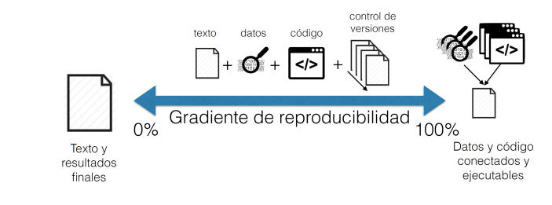

Investigación reproducible. Tomado de Rodríguez Sánchez et. al.

En principio sería suficiente con hacer públicos –siempre que sea posible– los datos y adjuntar las sintaxis con la que los analizamos. Sin embargo esto implica que debemos mantener sicronizadas “manualmente” tres estructuras diferentes: los datos, el código y el texto. En verdad es mucho más fácil hacer que todo esto funcione si contamos con una plataforma de software unificada que procese tanto los datos como el código y el texto y a partir de estos elementos produzca salidas en formatos compatibles con la publicación: LaTeX, .pdf., .docx, etc. Esa plataforma existe y es completamente gratuita: se llama R y gracias al trabajo voluntario de personas como [Yihui Xie](https://yihui.name/en/), autor de la librería knitr, ha simplificado enormemente el proceso de la investigación reproducible. Usar en conjunto knitr, pandoc y LaTeX desde Rstudio es en verdad muy fácil y estas de librerías se encargan de prácticamente todo el proceso de edición: ejecutan el código R, conservan y dan formato a los resultados, agregan números de figuras y tablas, crean la bibliografías, tablas de referencias cruzadas, númeran las páginas y, como si fuera poco, organizam la ubicación de tablas y gráficos en el documento, evitando páginas en blanco y gráficos recortados. Toda la cadena de software es open source y multiplataforma: corre exactamente igual en Linux, macOS o Windows.

¿Qué ventajas tiene la investigación reproducible? La ventaja para la comunidad de investigadores ya fue expuesta. Para cada investigador o investigadora también las tiene. La primera, también esbozada, es la *simplificación del flujo de trabajo* al utilizar una solo plataforma de software. Es innecesario pasar por el penoso trabajo de realizar el análisis en un programa –digamos, Stata–, copiar los resultados, formatearlos en otro –digamos, Excel para las tablas y/o un editor de gráficos para estos– y finalmente reunirlos en un documento de procesador de texto –digamos, Word; sólo para repetir la cadena cada vez que queremos introducir algún cambio, por mínimo que sea. Este proceso no solo es laborioso, también es propenso a errores y no deja rastros que nos permitan identificar con facilidad donde los cometimos: no hay una sintaxis o log del proceso, todo lo hicimos moviendo el ratón. Integrando todos los pasos en R los cambios, grandes o pequeños, se actualizan inmediatamente. Si hay error de sintaxis será ruidoso e interrumpirá el proceso, si hay un error conceptual o de otro tipo tendremos la sintaxis paso a paso de lo que hemos hecho y podremos identificarlo y solucionarlo. Podemos recorrer y validar el camino que nos lleva a nuestros resultados con gran facilidad. La segunda es la aplicación de *control de versiones*. Uno de verdad, como el que implementa el algoritmo Git, no el control de cambios de Word, que nadie en su sano juicio utiliza y por buenos motivos. Para el investigador individual significa que podemos ir hacia atrás y hacia adelante en el avance del documento, comparar cambios, regresar si el camino que tomamos no nos gusta. Esto hace obsoletas tanto las versiones con múltiples nombres de un mismo archivo como los documentos que reservamos para párrafos sueltos. Para los equipos de trabajo que no es necesario pasar versión tras versión por correo electrónico: texto y código están en un repositorio compartido y permamentemente actualizado que, si se dieran conflictos de versiones, los resuelve automáticamente. También posibilita abrir bifurcaciones para probar ideas nuevas sin alterar el original. Al final y si lo consideramos mejor podemos reunirlo con el original. La tercera es la posibilidad de *reutilizar nuestro propio trabajo*. No me refiero a hacer refritos para inflar el CV, me refiero a encontrarnos en el futuro con un problema que ya resolvimos y encontrar rápidamente esa solución para volver a implementarla.

¿Qué desafíos trae la investigación reproducible? El más inmediato es que posiblemente no estemos acostumbrados a utilizar las herramientas de software que lo implementan. No se trata de versiones diferentes de los paquetes de oficina o de análisis estadístico que usamos, se trata de software que emplea interfaces y metáforas totalmente diferentes. R, pandoc, LaTeX o Git no tienen ningún atisbo de isomorfismo, no intentan simular nuestras interacciones con objetos cotidianos para darnos una sensación de familiaridad o implementan menús para mostrarnos todas las opciones. Reciben sus comandos de manera escrita a través de una consola, misma en la que vemos los resultados, se manejan exclusivamente con archivos de texto que debemos editar con cuidado. Esta familia de software tiene una característica común: la curva de aprendizaje tiene pendiente alta al principio. R hace difícil lo fácil y fácil lo dificil, al menos en un comienzo.

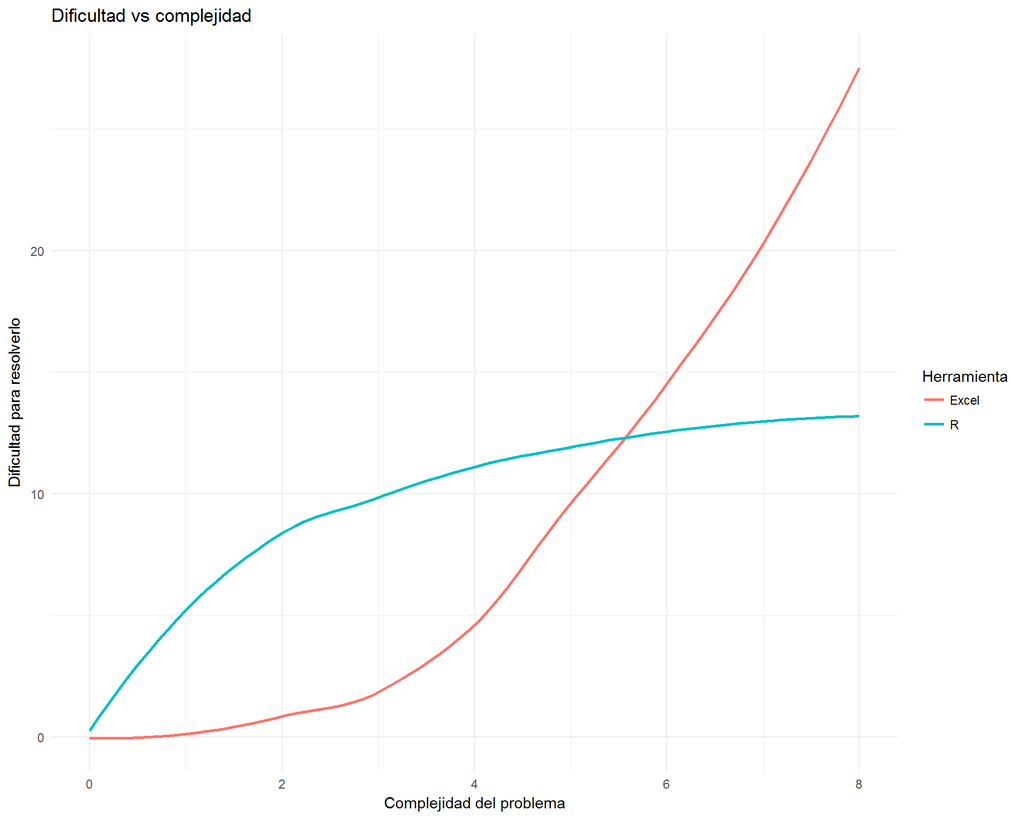

Curva de aprendizaje y dificultad de problemas.

```r
library(tidyverse)
tribble(~prog,  ~x, ~y,
        "Excel",  0, 0,
        "Excel",  1, 0,
        "Excel",  2, 1,
        "Excel",  3, 2,
        "Excel",  4, 4,
        "Excel",  5, 10,
        "Excel",  6, 15,
        "Excel",  7, 19,
        "Excel",  8, 28,
        "R",      0, 0,
        "R",      1, 6,
        "R",      2, 8,
        "R",      3, 10,
        "R",      4, 11,
        "R",      5, 12,
        "R",      6, 12.5,
        "R",      7, 13,
        "R",      8, 13.2
        ) %>% ggplot(aes(x=x, y=y, group=prog, color=prog)) +
                  geom_smooth(se=FALSE) +
                  labs(title="Dificultad vs complejidad",
                       x="Complejidad del problema",
                       y="Dificultad para resolverlo",
                       color="Herramienta",
                       aption="Adaptado de \n http://shotwell.ca/blog/post/r_for_excel_users/") +
                  theme_minimal()
```

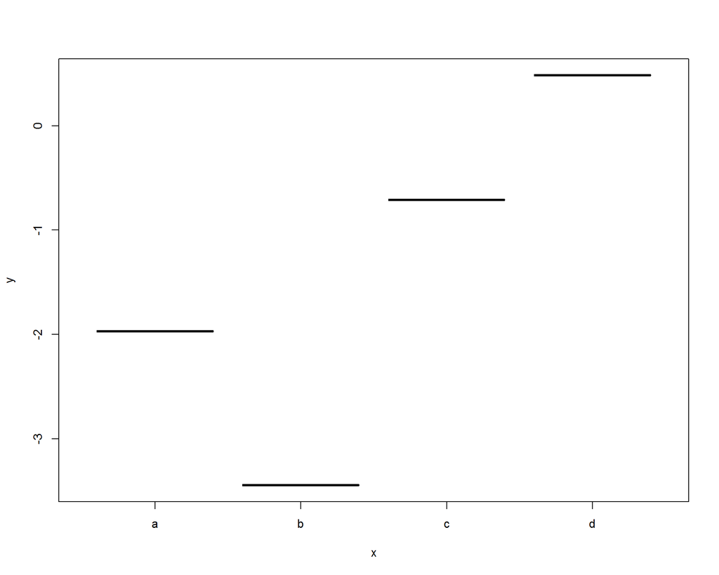

```r
#Programación imperatica en R: cada línea modifica el estado anterior del programa y asigna un nombre al cambio.
set.seed(1244)
x <- c("a", "b", "c", "d", NA)   #Creo el vector x
y <- rnorm(5, 0, 3)              #Creo el vector y: una normal aleatoria.
df <- data.frame (x=x, y=y)      #Los reuno en un data.frame
df <- na.omit(df)                #Elimino las filas con missing (NA)
plot(df)                        #Produzco un gráfico.
```

```r
#Entorno de trabajo imperativo: 3 efectos colaterales, un output.
ls()
```

```
## [1] "df" "x"  "y"
```

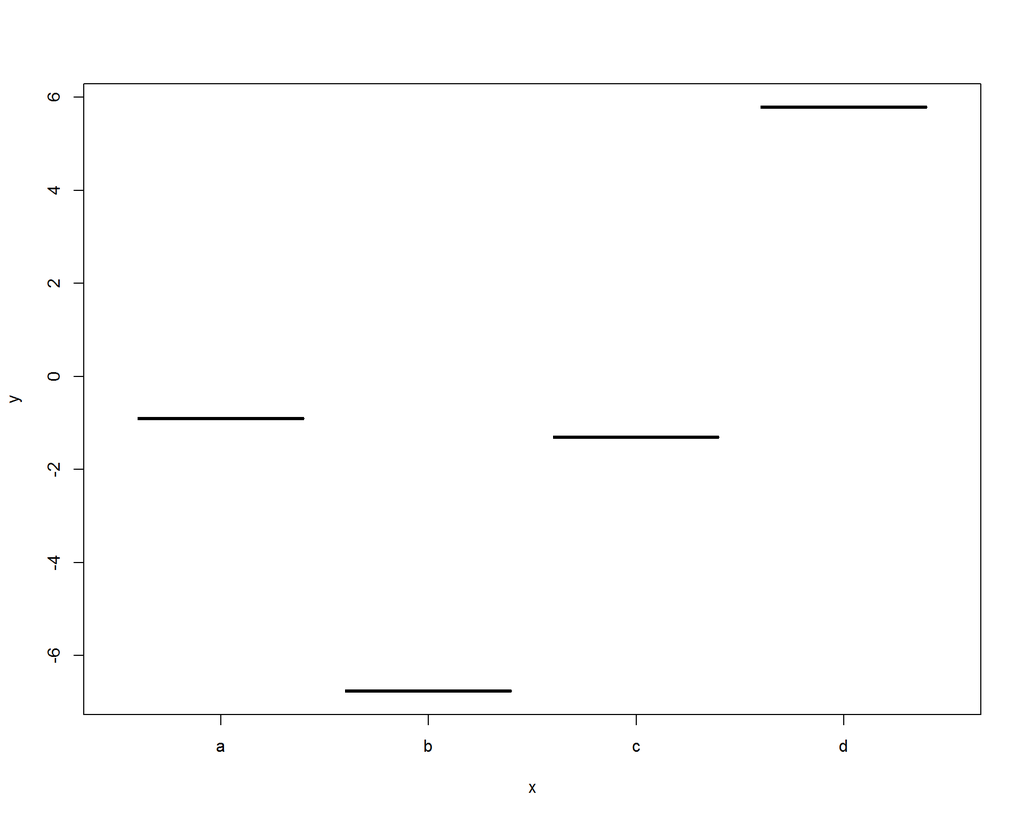

```r
rm(list=ls())                 #Borro el entorno de trabajo.


plot(na.omit(data.frame(x=c("a", "b", "c", "d", NA), y=rnorm(5, 0, 3))))  #Sólo output, 0 efectos colaterales.
```

```r
#Entorno de trabajo funcional. Nada por aquí... producimos output
ls()
```

```
## character(0)
```

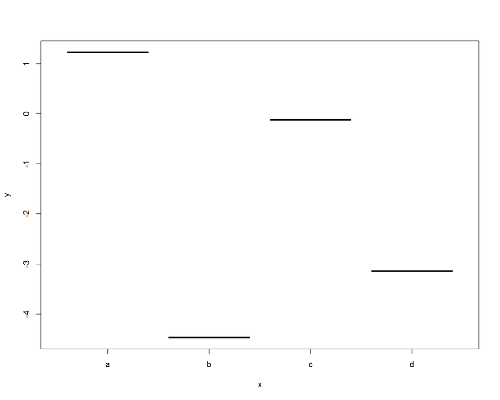

```r
#Versión legible con sangrado de código. R lo evalúa como una sola línea.

plot(
  na.omit(
    data.frame(
               x=c("a", "b", "c", "d", NA),
               y=rnorm(5, 0, 3)
               )
         )
    )
```

En lugar de ir transformando nuestros datos a lo largo del programa y registrando esos cambios asignándoles uno o más nombres crearemos los datos que necesitamos de manera ad hoc, en una cadena que inicia con los datos y culmina con el resultado esperado: una tabla, un gráfico, un modelo. Los datos no son un río que fluye y cambia de forma a medida avanza el programa: son un depósito del que sacamos una tubería cada vez que lo necesitamos. Si una se tapa las demás siguen funcionando. Seguiremos organizando nuestro código con una pauta de tiempo espacio: esto es investigación reproducible y los resultados de R deben estar en sincronizados con el texto que estamos escribiendo, que tiene su propia metáfora tiempo-espacio: más arriba es antes, más abajo después. Pero a los efectos ejecución del programa este es paralelo: hay una fuente inmutable de datos y multiples funciones que pueden procesarlos simultaneamente[^2]. Cada bloque está separado de los demás, no depende se sus resultados. Puedo eliminar bloques completos de código y el resto sigue funcionando. La integridad de los datos y el mantenimiento del código están garantizados.

[interactive chart not shown]

Esquema de los paradigmas funcional e imperativo

## Filosofía: programación funcional con inmutabilidad de datos, transparencia referencial y funciones puras.

R permite manipular datos de una forma sólo limitada por nuestra propia capacidad, es decir, es posible y probable que descubramos formas de corromper o deformar nuestros datos que nunca hubieramos imaginado. Dado que R no nos limita ni nos induce a determinadas maneras de programación es necesario que desarrollemos un conjunto de prácticas que eviten siempre que sea posible la corrupción de los datos y reduzcan la carga cognitiva del programador/analista reduciendo el número de objetos en el entornos. Las líneas siguientes no son un manual de procedimientos sino un breve y simplificado excurso sobre teoría de los lenguajes de programación y la forma en que podemos aprovecharla para crear prácticas y flujos de trabajo al mismo tiempo predecibles y flexibles que producen un código fácil de mantener. Con programas cortos y simples sobre los que estamos trabajando activamente el mantenimiento del código no es problemático: podemos recordar que hace cada línea y tener un registro mental de los nombres que vamos asignando a las estructuras de datos. Sabemos, por ejemplo, que `datos` son los datos originales, `datos2` una copia en la que recodificamos de cierto modo un variable y `datos` *después de la línea 25* incorporó esa recodificación. Sin embargo cuando el código crece en tamaño y complejidad y/o volvemos a trabajar sobre ese código después de un tiempo y ya no tenemos memorizadas las mutaciones a las que fuimos sometiendo a los datos a lo largo del programa estaremos ante un código dificil de mantener. Hacer una pequeña modificación -digamos, incorporar las observaciones de un dictamen- implicará varias horas de estudio de nuestro propio código hasta familiarizarnos nuevamente con la serie de transformaciones y estar en condiciones de hacer los cambios sin romper la sintaxis. La programación funcional es un paradigma de programación que elimina de raíz estos escenarios y está implementada en R desde sus orígenes.

R es un lenguaje multiparadigma, es decir, admite varias formas de obtener los mismos resultados. Pertinentes a este apartado son los paradigmas procedimentales y funcionales, ambos disponibles en R. Podemos combinarlos y de hecho en ocasiones no tendremos más alternativa que hacerlo, pero para evitar confusiones es mejor utilizar sólo uno de ellos y por lo ya dicho es todavía mejor utilizar solamente el paradigma funcional. Los conceptos clave del paradigma funcional que aplicaremos son la inmutabilidadd de los datos, las funciones puras y la transparencia referencial. Las funciones puras son aquellas que reciben un input y nos regresan un output y no producen efectos colaterales. Un efecto colateral es un efecto de la función que produce un cambio de estado del programa fuera del ámbito estricto esa función.[^3] Dado que no queremos cambiar estados más allá del imput-output de la función y que frecuentemente el resultado final esperado implica más de una función sería una buena idea poder encadenar funciones, de modo que el output de una sea el imput de la siguiente. Para esto nos ayuda la transparencia referencial, el último punto que tocaremos. La transparencia referencial es una propiedad de los lenguajes de programación que hace mutuamente reeemplazables en la sintaxis a expresiones equivalentes. Dado que `1/2 = 0.5` en R podemos usar uno u otro indistintamente. Si nos interesa trabajar sobre variable transformada esto significa que en lugar de crear primero esa variable transformada, guardarla en algún lugar y pasarla posteriormente a otra función llamar directamente a la función de tranformación en lugar mismo en el que lo necesitamos. La transparencia referencial se encarga hacer la transformación en el momento adecuado. Inclusive nos permite hacer subconjutos sobre el output de una función directamente en la llamada a la función. Así `rnorm(15, 0, 1)[3]` nos regresará el tercer valor del vector de número normales aleatorios que hemos creado, no es necesario asignar un nombre al vector y luego extraer el valor. Veamos algunas pruebas de estos conceptos en R aplicándolos a la estimación de una mediana y algunos problemas de de unión y separación de datos. La mediana es el valor que se ubica en el centro de un vector ordenado. Para obtenerla debemos primero ordenar al vector, luego ubicar la posición que divide al vector en 2 partes iguales y finalmente ver cuál es el valor que ocupa esa posición, es decir, $M_e=x_{(n+1)/2}$.

```r
#Bloque 1

#Captura de datos.

x <- c(100000, 1, 2, 3, 4, 5, 6, 100, 1000) #Creo el vector "x" con valores numéricos. Se mantendrá inmutable a lo largo de todo el ejercicio.
y <- c("a", "b", "c", "d", "e", "f", "g", "h", "i") #El vector y tiene valores caracter.

#Inmutabilidad de los datos
#==========================
#Realizo una serie de operaciones sobre x y y, pero estos permanecen iguales.

x                       #Imprimo x
```

```
## [1] 1e+05 1e+00 2e+00 3e+00 4e+00 5e+00 6e+00 1e+02 1e+03
```

```r
data.frame(y=y, x=x)    #Combino x y y en una estructura rectangular
```

```
##   y     x
## 1 a 1e+05
## 2 b 1e+00
## 3 c 2e+00
## 4 d 3e+00
## 5 e 4e+00
## 6 f 5e+00
## 7 g 6e+00
## 8 h 1e+02
## 9 i 1e+03
```

```r
x*x                     #x al cuadrado
```

```
## [1] 1.0e+10 1.0e+00 4.0e+00 9.0e+00 1.6e+01 2.5e+01 3.6e+01 1.0e+04 1.0e+06
```

```r
median(x)               #x mediana de x
```

```
## [1] 5
```

```r
x                       #x nunca se modificó
```

```
## [1] 1e+05 1e+00 2e+00 3e+00 4e+00 5e+00 6e+00 1e+02 1e+03
```

```r
#Funciones puras. Estimación de una mediana para vectores de largo impar.
#========================================================================


#Sin efectos colaterales, solo recibe x y regresa la mediana..

sort(x)[(length(x)+1)/2]
```

```
## [1] 5
```

```r
x                          #x se mantiene igual.
```

```
## [1] 1e+05 1e+00 2e+00 3e+00 4e+00 5e+00 6e+00 1e+02 1e+03
```

```r
#Con efectos colaterales.

n <- length(x)
x <- sort(x)
posicion <- (n+1)/2
x [posicion]               #Regresa la mediana.
```

```
## [1] 5
```

```r
x                          #Efecto colateral: reordenó x.
```

```
## [1] 1e+00 2e+00 3e+00 4e+00 5e+00 6e+00 1e+02 1e+03 1e+05
```

```r
n;posicion                 #También agregó dos objetos al entorno que no volveremos a utilizar.
```

```
## [1] 9
```

```
## [1] 5
```

```r
data.frame(y=y, x=x)       #Corrupción de datos: no coinciden las filas.
```

```
##   y     x
## 1 a 1e+00
## 2 b 2e+00
## 3 c 3e+00
## 4 d 4e+00
## 5 e 5e+00
## 6 f 6e+00
## 7 g 1e+02
## 8 h 1e+03
## 9 i 1e+05
```

```r
#Transparencia refencial.
#========================

median(x) == sort(x)[(length(x)+1)/2]     #Igualdad de dos expresiones.
```

```
## [1] TRUE
```

```r
z <- sort(x, decreasing=TRUE)            #Reordeno x de mayor a menor, lo asingo a z.

z
```

```
## [1] 1e+05 1e+03 1e+02 6e+00 5e+00 4e+00 3e+00 2e+00 1e+00
```

```r
z[1]                                      #z en la posición 1
```

```
## [1] 1e+05
```

```r
sort(x, decreasing = TRUE)[1]             #Podemos usar las expresiones z[1] y sort(x, decreasing = TRUE)[1] de manera totalmente equivalente. Ambas son la misma referencia para R.
```

```
## [1] 1e+05
```

```r
data.frame(y=y, x=log(x))
```

```
##   y          x
## 1 a  0.0000000
## 2 b  0.6931472
## 3 c  1.0986123
## 4 d  1.3862944
## 5 e  1.6094379
## 6 f  1.7917595
## 7 g  4.6051702
## 8 h  6.9077553
## 9 i 11.5129255
```

```r
data.frame(y=y, x=x, z=log(x))
```

```
##   y     x          z
## 1 a 1e+00  0.0000000
## 2 b 2e+00  0.6931472
## 3 c 3e+00  1.0986123
## 4 d 4e+00  1.3862944
## 5 e 5e+00  1.6094379
## 6 f 6e+00  1.7917595
## 7 g 1e+02  4.6051702
## 8 h 1e+03  6.9077553
## 9 i 1e+05 11.5129255
```

```r
z                                          #z no se modificó, z=log(x) sólo es válido dentro de la función.
```

```
## [1] 1e+05 1e+03 1e+02 6e+00 5e+00 4e+00 3e+00 2e+00 1e+00
```

```r
#Función para estimar la mediana en vectores pares impares.

ifelse(length(x)%%2 == 0,                                                       #%%Regresa el resto de la división, si es igual a 0 length(x) es par.
      (sort(x)[floor((length(x)+1)/2)] + sort(x)[ceiling((length(x)+1)/2)])/2,  #length(x) par, promedio de los valores centrales.
      sort(x)[(length(x)+1)/2]                                                  #length(x) par: valor central.
      )
```

```
## [1] 5
```

Como vemos en el Bloque 1 R se maneja tanto dentro de un paradigma procedimental –en el que modificamos estado del programa o de los datos línea por línea- como dentro de un paradigma funcional, en el que nunca modificamos el estado del programa o la estructura de los datos de modo que afecte al código siguiente. Cuando modificamos los datos lo hacemos *dentro* de funciones. De este modo x será siempre x, a lo largo de todo el programa, con los mismos datos en el mismo orden. Así se reduce notablemente la carga cognitiva del programador/analista, no es necesario verificar en cada paso que los datos no han perdido su integridad. R se encarga de administrar los nombres de los objetos, por lo tanto no son necesarias una convención y disciplina estrictas para nombrar objetos. También evitamos completamente llevar a cabo prácticas riesgosas como el reciclado de nombres.[^4]

### CODA:

**Use el asignador `<-` cuando sea estrictamente indispensable.**

- Su uso se justifica solamente cuando hay una penalización de desempeño muy alta.
- Como regla general, sólo asigne nombre a objetos cuya producción requiere demasiado tiempo.
- Importar datos leyéndolos de un archivo suele ser un proceso lento, hágalo sólo una vez al principio del programa y asigne un nombre al objeto resultante.
- Lo mismo vale para alguna transformación basada en un algortimo complejo y que utilizará recurrentemente.
  - Por ejemplo, los modelos con efectos aleatórios para n grande son complejos de resolver y analizaremos en profundidad el resultado. En este caso un nombre al resultado en lugar de llamar a la función que produce el modelo una y otra vez.
  - Las recodificaciones, partición de datos y unión de bases son muy rápidas en R y propensas a generar errores en el código que les sigue. Nunca asigne nombre en estos casos, llame directamente a la función pertinente.
- Por su paz mental nunca recible nombres: un objeto distinto requiere un nombre distinto. Nunca debería crear líneas del tipo `datos <- datos[algo]`, `datos_algo <- datos[algo]` es una mejor alternativa.
- Si aún así prefiere asignar nombres a los datos transformados use una convención clara y sea estricto al respecto. El data.frame en el que recodificó la variable V3 deberían llamarse `datos_recodificados_V3_dicotomica` o algo por el estilo. Nunca `datos2`, `datos_reco` u otros nombres que no le dan información sobre lo que contienen. Cuando lo escriba recordará perfectamente que hay ahí, en unos meses no. Si preferiría no tener que tiepar nombres tan largos puede usar programación funcional y simplemente no tendrá que tipear ningún nombre.

**Use funciones siempre que sea posible.**

- En lugar de generar múltiples copias de un objeto a medida que lo transforma, genere múltiples funciones que hacen esas transformaciones sin efectos colaterales y llámelas cada vez que necesita los datos transformados.
- Asegúrese de que las funciones que utiliza, incluyendo las que usted crea, sea puras. Sólo imput y output.
- R permite funciones lambda, es decir, funciones anónimas. Úselas para funciones ad hoc que no volverá a utilizar.
- Si nota que está copiando y pengando código con frecuencia considere convertir ese código en una función. De este modo evitará posible errores en el copiado/pegado.
  - De ese modo si quiere hacer algún cambio a la sintaxis lo hará directamente en la función, produciendo efectos sobre todo el código que llama a esa función. No será necesario repetir el cambio en cada aparición de ese código.
- En la programación funcional los paréntesis reemplazan al salto de línea para organizar el orden de ejecución del programa. Esto que puede dificultar la lectura del código.
- Utilice tuberías para encadenar funciones. Tendrá un código mucho más legible.
- Utilice sangrías para hacer más legible su código: cada función y/o sus argumentos deberían estar en línea aparte.
- El único efecto colateral de la programación funcional es que tendrá que contar paréntesis. Si se toma el trabajo adicional de alinearlos será más fácil ubicar cuál abre y cual cierra cada función.
- Al finalizar su análisis su entorno de trabajo debería tener sólamente la o las fuentes de datos originales y las funciones con las que las transforma, nunca 15 o 20 versiones levemente diferentes y con nombres parecidos de los mismos datos.

# Redacción anterior.

La aproximación de `dplyr::`[^5] tiene ventajas demasiado grandes para pasarlas por alto. Combinado con `margittr::`, una librería que extiende las capacidades de R y permite utilizar tuberías para enlazar funciones `dplyr::` convierte a R en un lenguaje moderno que produce código elegante, legible y fácil de mantener. Esto nos permitirá enfocarnos en lo que nos interesa, el análisis de datos. Cada minuto que nos ahorremos dando mantenimiento a nuestro código o arreglando una estructura de datos que se corrompió es un minuto más analizando datos. La mayor de estas ventajas, sin duda, es que nos permite sacar provecho de uno de los paradigmas más importantes del lenguaje R: la programación funcional y la consiguiente inmutabilidad de los datos. Si usamos dplyr apropiadamente asignaremos nombre a los datos sólo una vez, al inicio del análisis. Todas las transformaciones necesarias para cierta operación (limpieza, recodificación, etc.) se llevan a cabo dentro de una cadena de funciones claramente legible que nunca cambiara los datos originales. Esto garantiza la integridad de los datos y por consiguiente de los resultados. Los errores que cometamos -y lo haremos- serán errores explícitos y ruidosos, que se manifestarán en el punto en el que ocurren, no al final del proceso. Esto nos ahorrará el tiempo que pasaríamos rastreando y corriegiendo errores que se propagan por todo el código cuando realizamos un cambio en los datos en un punto que tiene efectos colaterales sobre el código que sigue. Así, por ejemplo, cambiamos un nombre de columna para que se imprima en un gráfico e inadvertidamente rompemos el código que sigue, ya que este esperaba el nombre original. Si, para evitar este problema, multiplicamos los nombres que asignamos a los datos, nos obligamos a rastrear decenas de objetos con nombres y estructuras muy parecidos, tratando de adivinar cuál es la correcta para cada caso. Es perfectametne posible trabajar de este modo y sin duda es una aproximación más directa. Pero el ahorro de tiempo inicial se desvanecerá cuando haya un problema. Una hora rastreando el lugar del código más arriba que rompe el código más abajo es una hora menos que dedicamos al análisis de datos. Si el código es suficientemente complejo nuestros “arreglos” seguramente romperán otra parte del código y así hasta la frustración.[^6] La programación funcional elimina de raíz los efectos colaterales. La sintaxis tradicional de R permite ajustarnos al paradigma de programación funcional anidando funciones entre paréntesis. Esto es un avance con respecto asignar nombre al resultado de cada función, pero el código que produce es difícil del leer, el resultado está primero, los procesos se organizan en el orden inverso al que se ejecutan. Si esto fuera poco nos obliga a rastrear y contar los paréntesis que organizan el código. Las tuberías que utiliza `dplyr::` producen, en cambio, un código legible y por tanto fácil de mantener. Véa el siguiente ejemplo, en el que hacemos pizza con tres paradigmas de programación:

### Pizzería “El asignador”. Pizzas de hoy y de ayer.

```r
#Pizzería "El asignador"
ingredientes_masa <- c(harina, agua, levadura)
ingredientes_salsa <- c(ajo, tomate, cebolla)
salsa <- cocinar(ingredientes_salsa)
masa <- amasar(ingredientes_masas)
masa_estirada <- estirar(masa)
prepizza <- salsear (masa_estirada, salsa)
pizza <- hornear (prepizza)
```

### Pizzería La funcional clásica.

```r
#Pizzero La funcional
pizza(
  hornear(
    salsear(c(ajo, tomate, cebolla),
            estirar(
              amasar(c(harina, agua, levadura)
                    )
                   )
           )
         )
     )
```

### Pizzería magrittr ¡La más %>% del rumbo!

```r
#Pizzería magrittr, de René Magritte e hijos.
c(harina, agua, levadura) %>%
  amasar %>%
  estirar %>%
  salsear (c(ajo, tomate, cebolla) %>%
  hornear
```

El sabor es el mismo y si todo marcha bien jamás notaremos la diferencia.

Sin embargo el proceso es diferente. Si la pizza del asignador tiene problemas el pizzero deberá rastrear siete objetos para identificar en cuál está el problema. Quizás le quedó `masa_estirada` del día de ayer[^7], entonces no está seguro si la pizza que sale del horno tiene `masa_estirada` fresca o una que quedó de ayer.

El pizzero funcional ni siquiera le da un nombre al objeto que está manipulando, sólo le interesa el proceso. Simplemente le pasa el resultado de ese proceso al cliente (¡otra función!) cuando este la requiere. Hace pizza cada vez que le piden, no tiene un inventario al que estar rastreando. Pero si no lee la receta con cuidado podría poner primero la salsa y después la masa, ya que la receta comienza con el resultado y no con las materias primas. Y no digamos nada del trabajo que le daría cambiar su receta para agregar queso a la pizza o ponerle salsa hasta las orillas a pedido de un cliente. A contar paréntesis y ubicar la línea exácta en la que pasar un argumento adicional a una función.

En Pizzería mgrittr empezamos por los ingredientes y terminamos con el horneado. Si queremos agregar un ingrediente o modificar un proceso simplemente lo ubicamos en el lugar obvio. El queso va después de salsear y antes de hornear. `cubrir_borde` es un argumento que pasamos a la función salsear, que identificamos inmediatamente en el código. La receta es legible de una forma intuitiva, comienza por las materias primas y termina en el horneado. Es fácil identificar cada paso y modificarlo de acuerdo a las necesidades del momento.

[^1]: mpaladino@mora.edu.mx
[^2]: No es extraño que la programación funcional sea utilizada en aplicaciones que requieren procesamiento paralelo aprovechando los múltiples núcleos de procesamiento de las computadoras. Lamentablemente R, en su versión actual, tiene pocas capacidades para aprovechar el paralelismo implícito en el paradigma funcional. Ojalá esto cambie. Si escribimos código funcional podremos aprovechar ese paralelismo.
[^3]: Evidentemente no consideramos al output de la función como un efecto colateral.
[^4]: Reciclamos nombres cuando en una misma sintaxis utilizamos el mismo nombre para objetos no identicos. Por ejemplo, el objeto `datos` al comienzo tiene determinada información y estructura, en un punto del programa por una necesidad puntual lo modificamos -digamos, recodificamos algunas de las variables- y mantenemos el nombre `datos`. Aquí hay dos problemas posibles: 1) Que necesitemos nuevamente los datos originales y debamos modificar una vez más `datos` para regresarlo a su forma original o, peor aún, que la recodificación falle por algún error pero R no detenga la ejecución, ya que la línea de código que invoca a `datos` recibirá un objeto con ese nombre, aunque con la información incorrecta. A esto nos referimos con *errores silenciosos*.
[^5]: Siempre que se lea una expresión en letra monoespaciada seguida de dos veces dos puntos estaremos haciendo referencia a una librería.
[^6]: Esto es aún peor cuando queremos realizar una actualización o mantenimiento del código tiempo después de haberlo escrito. ¿Qué era datos2? ¿Por qué no hay recodificaciones en datos_reco?
[^7]: Esto es un muy frecuente: si repetimos los nombres de los objetos estos quedarán en nuestro entorno, cargados de datos. Luego, digamos, ajustamos un modelo sobre los datos con ese nombre a los que recodificamos para el caso. Si esta recoficación fallara por un error de sintaxis el modelo se ejecutará igual -pues sigue encontrando un objeto con ese nombre. Esto esproduce un error silencioso, que no advertiremos hasta el resultado final, si es que lo advertimos.